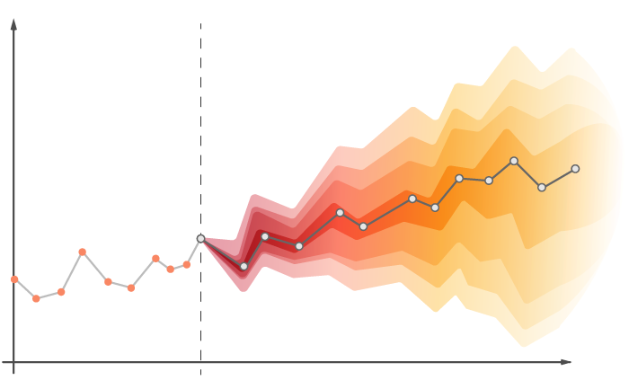

# BUSINESS FORECASTING

## TEAM 2

#### GROUP MEMBERS

MERIN GEORGE (20BDA11)

ANJU MARIA RAJU (20BDA19)

AADHYA SHARMA (20BDA40)

CHANDAN J R (20BDA51)

RANJITH KUMAR K.N (20BDA56)

MARIYA BIJU (20BDA61)

# PROBLEM STATEMENT

Neo Bank of India (a fictional bank) receives a lot of requests for its various finance offerings that include housing loans, two-wheeler loans, real estate financing, and microloans. The number of applications received is something that varies a lot with the season. Going through these applications is a manual and tedious process.The aim of the model is to forecast daily cases for the next 1 month for 2 different business segments aggregated at the country level.

## DATA DESCRIPTION

The train dataset contains variables such as

- application_date : The date application was recieved.
- segment : The business segment.
- branch_id : ID of the corresponding branch.
- state : State to which branch belongs to.
- zone : Zone to which the branch belongs to.

There are a total of 77432 datapoints.

# IMPORTING LIBRARIES

```r
library(readr)
library(dplyr)
library(lubridate)
library(reshape)
library(reshape2)
library(tidyr)
library(tidyverse)
library(bizdays)
library(timeDate)
library(ggplot2)
library(plotly)
library(timeSeries)
library(fpp2)
library(forecast)
library(tseries)
library(MASS)
library(xts)
library(data.table)
library(tsibble)
library(ggfortify)
library(fable)
library(zoo)
library(bizdays)
library(ggeasy)
library(harrypotter)
library(bizdays)
library(timeDate)
library(astsa)
```

# PREPROCESSING

```r
train = data.frame(read.csv("train.csv"))
test = data.frame(read.csv("test.csv"))
head(train)
```

```
##   application_date segment branch_id       state  zone no_of_applicants
## 1       01-04-2017       1         1 WEST BENGAL  EAST               40
## 2       01-04-2017       1         3       DELHI NORTH               58
## 3       01-04-2017       1         5   KARNATAKA SOUTH               10
## 4       01-04-2017       1         7 WEST BENGAL  EAST                2
## 5       01-04-2017       1         8 WEST BENGAL  EAST               13
## 6       01-04-2017       1         9 WEST BENGAL  EAST               11
```

```r
head(test)
```

```
##   id application_date segment
## 1  1       06-06-2019       1
## 2  2       07-06-2019       1
## 3  3       08-06-2019       1
## 4  4       09-06-2019       1
## 5  5       10-06-2019       1
## 6  6       11-06-2019       1
```

```r
str(train)
```

```
## 'data.frame':    77432 obs. of  6 variables:
##  $ application_date: chr  "01-04-2017" "01-04-2017" "01-04-2017" "01-04-2017" ...
##  $ segment         : int  1 1 1 1 1 1 1 1 1 1 ...
##  $ branch_id       : int  1 3 5 7 8 9 10 11 13 14 ...
##  $ state           : chr  "WEST BENGAL" "DELHI" "KARNATAKA" "WEST BENGAL" ...
##  $ zone            : chr  "EAST" "NORTH" "SOUTH" "EAST" ...
##  $ no_of_applicants: int  40 58 10 2 13 11 0 9 1 0 ...
```

The dataset contains 77432 datapoints and includes data of 2 business segments with branch_id,state, zone being the other variables contributing to the number of applicants.

```r
summary(train)
```

```
##  application_date      segment        branch_id        state
##  Length:77432       Min.   :1.000   Min.   :  1.0   Length:77432
##  Class :character   1st Qu.:1.000   1st Qu.: 36.0   Class :character
##  Mode  :character   Median :1.000   Median : 82.0   Mode  :character
##                     Mean   :1.168   Mean   :118.8
##                     3rd Qu.:1.000   3rd Qu.:248.0
##                     Max.   :2.000   Max.   :271.0
##                                     NA's   :13024
##      zone           no_of_applicants
##  Length:77432       Min.   :    0.0
##  Class :character   1st Qu.:    0.0
##  Mode  :character   Median :   17.0
##                     Mean   :  184.9
##                     3rd Qu.:   60.0
##                     Max.   :13787.0
##
```

### Converting applicate date into relevant date format

```r
train$application_date<-as.Date(train$application_date,format = "%d-%m-%Y")
test$application_date<-as.Date(test$application_date,format = "%d-%m-%Y")
```

### Converting segments to character format

```r
train$segment<-as.character(train$segment)
test$segment<-as.character(test$segment)
```

```r
colSums(is.na(train))/nrow(train)*100
```

```
## application_date          segment        branch_id            state
##          0.00000          0.00000         16.81992          0.00000
##             zone no_of_applicants
##          0.00000          0.00000
```

```r
train_1<-train[,c("segment","application_date","no_of_applicants")]
train_2 <- setDT(train_1)[,.(No_cases = mean(no_of_applicants)), by = c("segment","application_date")]
train_3 <- setDT(train_1)[,.(No_cases = mean(no_of_applicants)), by = c("segment","application_date")]
```

```r
head(train_2)
```

```
##    segment application_date   No_cases
## 1:       1       2017-04-01  3.6024096
## 2:       1       2017-04-03  0.5060241
## 3:       1       2017-04-04  0.2771084
## 4:       1       2017-04-05 18.4337349
## 5:       1       2017-04-07 16.1566265
## 6:       1       2017-04-12 17.6867470
```

```r
tail(train_2)
```

```
##    segment application_date No_cases
## 1:       2       2019-06-18 2020.312
## 2:       2       2019-06-19 1960.000
## 3:       2       2019-06-20 1890.938
## 4:       2       2019-06-21 1787.062
## 5:       2       2019-06-22 1616.438
## 6:       2       2019-06-23  820.375
```

### Splitting date into Day, Month, Year, Month-Year variables

```r
train_3$Day<-format(train_2$application_date,"%d")
train_3$Month<-format(train_2$application_date,"%m")
train_3$Year<-format(train_2$application_date,"%Y")
train_3$MonYr = as.yearmon(train_2$application_date) #Extracting yearly
```

### Segmenting Data

```r
seg_1<-subset(train_3,train_3$segment == 1)
seg_1$segment<-NULL

seg_2<-subset(train_3,train_3$segment == 2)
seg_2$segment<-NULL
```

```r
dim(seg_1)
```

```
## [1] 776   6
```

```r
dim(seg_2)
```

```
## [1] 814   6
```

Segment 1 contains 776 datapoints and segment 2 contains 814 datapoints.

```r
head(seg_1)
```

```
##    application_date   No_cases Day Month Year    MonYr
## 1:       2017-04-01  3.6024096  01    04 2017 Apr 2017
## 2:       2017-04-03  0.5060241  03    04 2017 Apr 2017
## 3:       2017-04-04  0.2771084  04    04 2017 Apr 2017
## 4:       2017-04-05 18.4337349  05    04 2017 Apr 2017
## 5:       2017-04-07 16.1566265  07    04 2017 Apr 2017
## 6:       2017-04-12 17.6867470  12    04 2017 Apr 2017
```

```r
tail(seg_1)
```

```
##    application_date No_cases Day Month Year    MonYr
## 1:       2019-05-31 44.78313  31    05 2019 May 2019
## 2:       2019-06-01 32.33735  01    06 2019 Jun 2019
## 3:       2019-06-02 23.46988  02    06 2019 Jun 2019
## 4:       2019-06-03 54.45783  03    06 2019 Jun 2019
## 5:       2019-06-04 57.31325  04    06 2019 Jun 2019
## 6:       2019-06-05 40.72289  05    06 2019 Jun 2019
```

```r
head(seg_2)
```

```
##    application_date No_cases Day Month Year    MonYr
## 1:       2017-04-01  56.0625  01    04 2017 Apr 2017
## 2:       2017-04-02  37.8125  02    04 2017 Apr 2017
## 3:       2017-04-03 126.0000  03    04 2017 Apr 2017
## 4:       2017-04-04 140.3125  04    04 2017 Apr 2017
## 5:       2017-04-05 150.9375  05    04 2017 Apr 2017
## 6:       2017-04-06 148.6875  06    04 2017 Apr 2017
```

```r
tail(seg_2)
```

```
##    application_date No_cases Day Month Year    MonYr
## 1:       2019-06-18 2020.312  18    06 2019 Jun 2019
## 2:       2019-06-19 1960.000  19    06 2019 Jun 2019
## 3:       2019-06-20 1890.938  20    06 2019 Jun 2019
## 4:       2019-06-21 1787.062  21    06 2019 Jun 2019
## 5:       2019-06-22 1616.438  22    06 2019 Jun 2019
## 6:       2019-06-23  820.375  23    06 2019 Jun 2019
```

## Tsibble dataframe for interpolated missing dates and their respective number of applicants is given as zero

```r
seg_1a<-subset(train_2,train_2$segment == 1)
seg_1a$segment<-NULL

seg_2a<-subset(train_2,train_2$segment == 2)
seg_2a$segment<-NULL
seg_1_ts <- as_tsibble(seg_1a,index = application_date)
seg_2_ts <- as_tsibble(seg_2a,index = application_date)
seg_1_ts<-fill_gaps(seg_1_ts)
seg_1_ts<-seg_1_ts %>% replace_na(list(No_cases = 0))
seg_1_ts
```

```
## # A tsibble: 796 x 2 [1D]
##    application_date No_cases
##    <date>              <dbl>
##  1 2017-04-01          3.60
##  2 2017-04-02          0
##  3 2017-04-03          0.506
##  4 2017-04-04          0.277
##  5 2017-04-05         18.4
##  6 2017-04-06          0
##  7 2017-04-07         16.2
##  8 2017-04-08          0
##  9 2017-04-09          0
## 10 2017-04-10          0
## # ... with 786 more rows
```

```r
seg_2_ts<-seg_2_ts %>% replace_na(list(No_cases = 0))
seg_2_ts
```

```
## # A tsibble: 814 x 2 [1D]
##    application_date No_cases
##    <date>              <dbl>
##  1 2017-04-01           56.1
##  2 2017-04-02           37.8
##  3 2017-04-03          126
##  4 2017-04-04          140.
##  5 2017-04-05          151.
##  6 2017-04-06          149.
##  7 2017-04-07          141.
##  8 2017-04-08          144.
##  9 2017-04-09           89.7
## 10 2017-04-10          198.
## # ... with 804 more rows
```

## Time series dataframe

```r
seg_1_ts1 <- ts(seg_1$No_cases, start=c(2017,04,01), end=c(2019,06,05),frequency = 365)
seg_2_ts2 <- ts (seg_2$No_cases, start =c(2017,04,01), end =c(2019,06,23),frequency=365)
```

# EXPLORATORY DATA ANALYSIS

## Explorartory Data Analysis For Segment 1

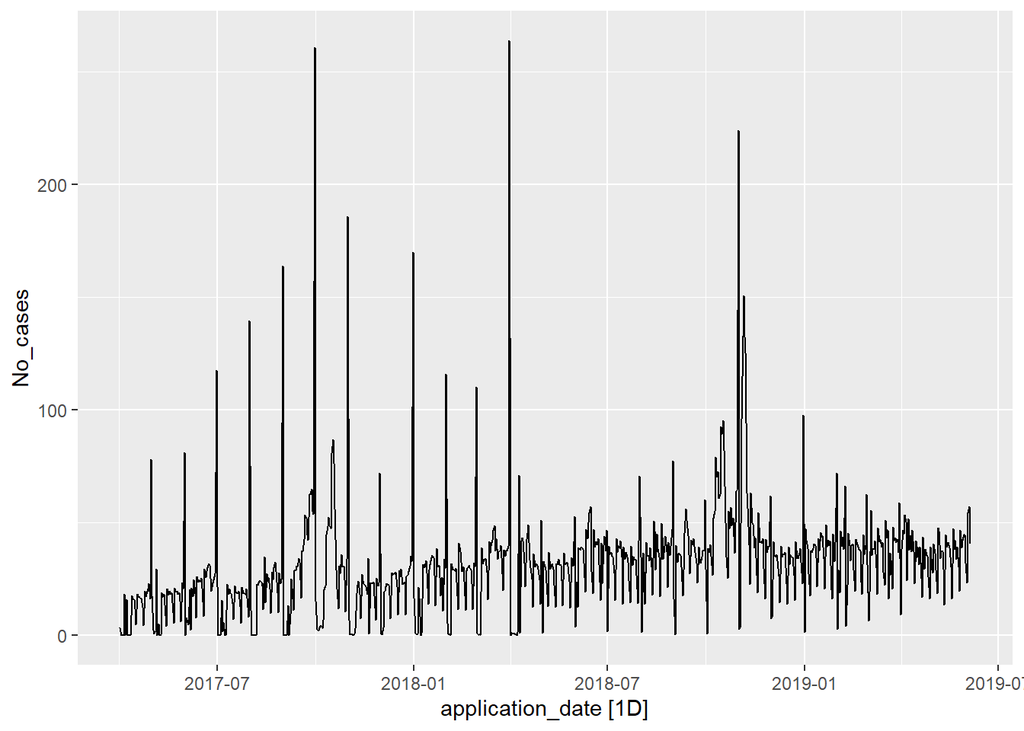

```r
seg_1_ts %>% autoplot(No_cases)
```

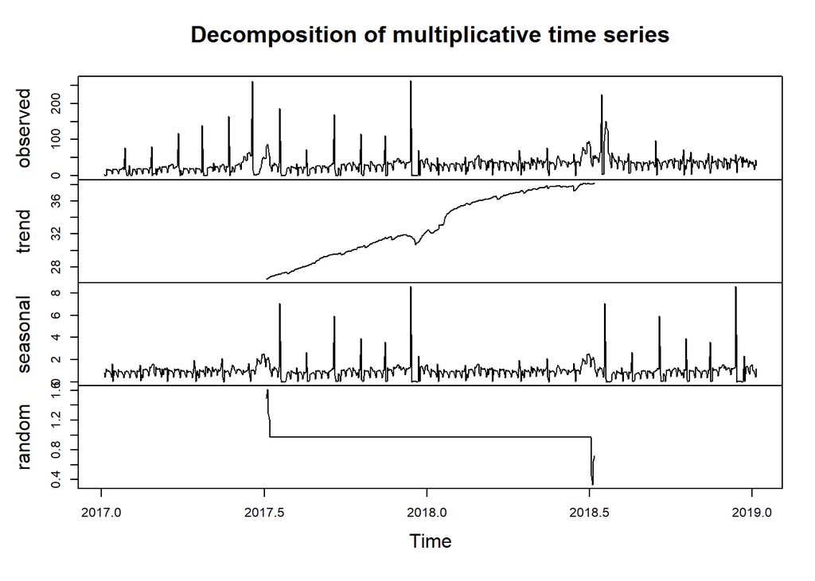

```r
tsdata_decom <- decompose(seg_1_ts1, type = "multiplicative")
plot(tsdata_decom)
```

Here we can observe a trend but seasonality is not observed.

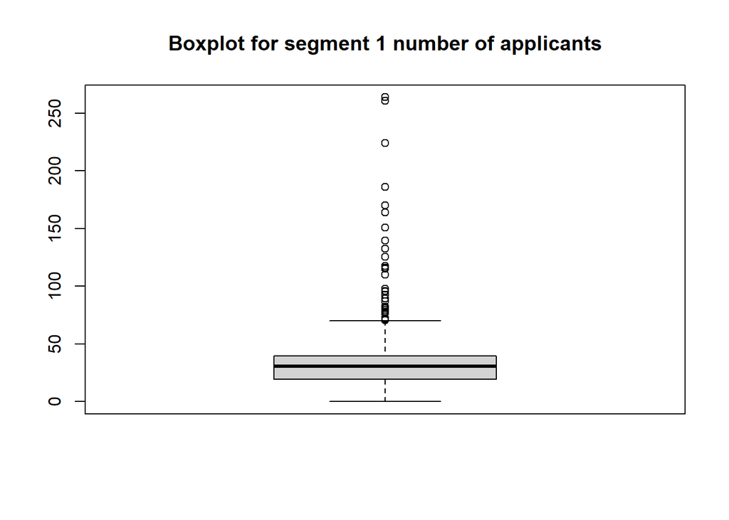

```r
boxplot(seg_1_ts1,main ="Boxplot for segment 1 number of applicants")
```

The output variable contains outliers.

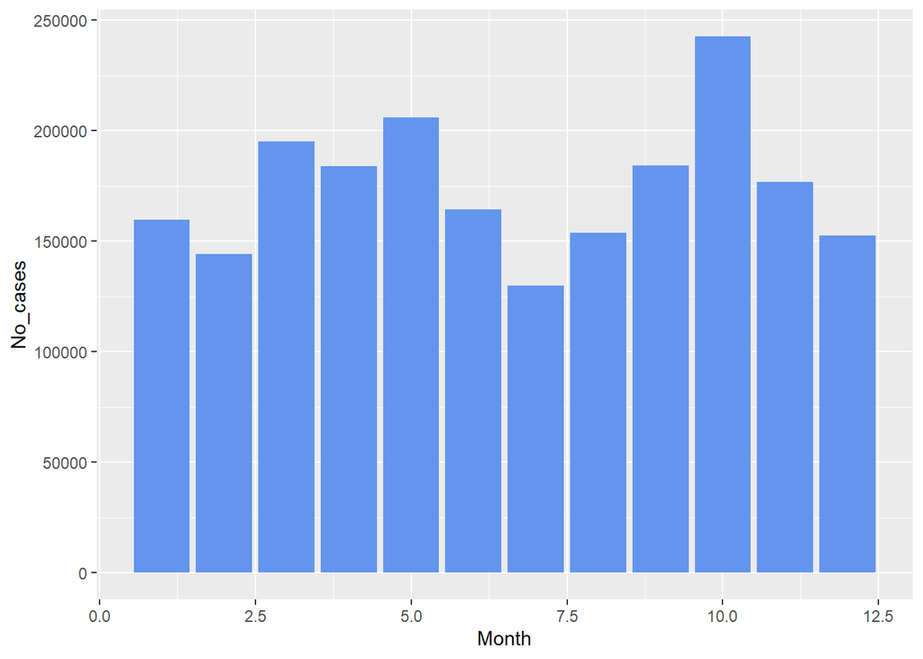

```r
month_summary <-df_segment1 %>%
                    group_by(Month) %>%
                    summarise(No_cases= sum(no_of_applicants),.groups='drop')
ggplot(month_summary,
       aes(x = Month,
           y = No_cases)) +
   geom_text(aes(label = No_cases),
            size = 3,
            position = position_stack(vjust = 0.5)) +
  geom_bar(stat = "identity",fill = "cornflowerblue")
```

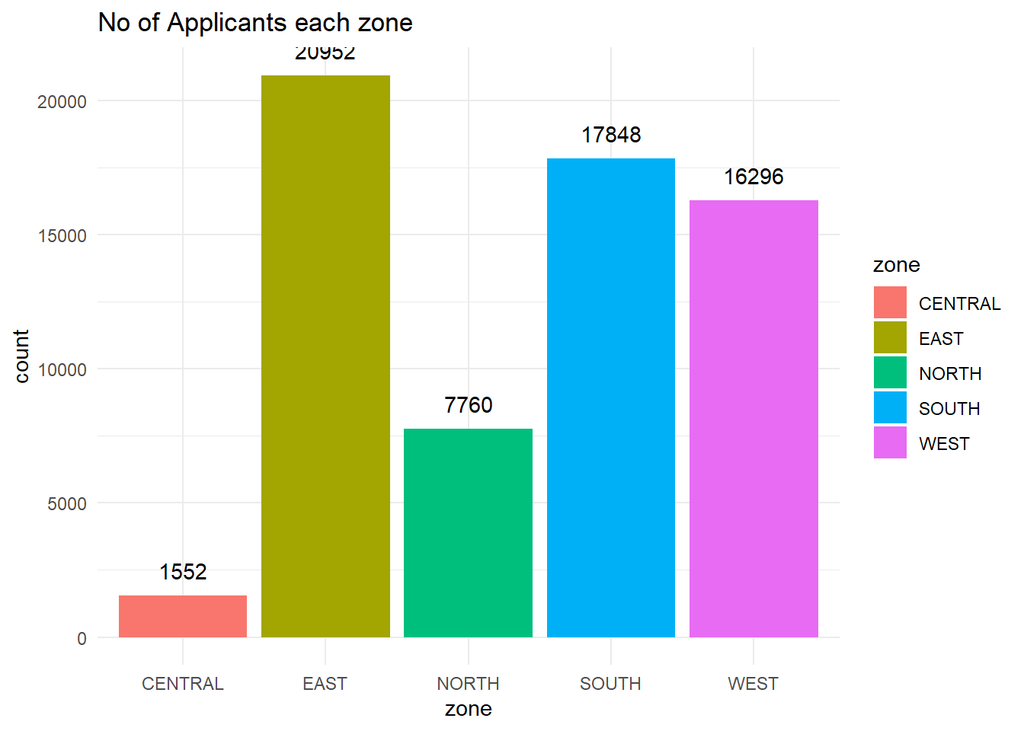

```r
# no of applicants from each zone
ggplot(data=df_segment1, aes(x=zone, fill = zone)) +
  geom_bar() +
  geom_text(stat='count', aes(label=..count..), vjust=-1)+
  ggtitle("No of Applicants each zone") +
  theme_minimal()
```

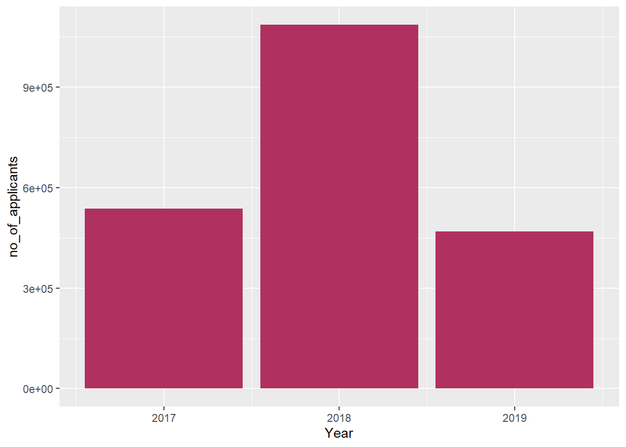

```r
f<-df_segment1 %>%
          group_by(Year ) %>%
          summarise(no_of_applicants= sum(no_of_applicants),.groups='drop')
ggplot(f,
       aes(x = Year,
           y = no_of_applicants)) +
   geom_text(aes(label = no_of_applicants),
            size = 3,
            position = position_stack(vjust = 0.5)) +
  geom_bar(stat = "identity",fill = "maroon")
```

The year 2018 contains the most number of applicants.The count of applicants for the year 2017 and 2019 is almost the same.

## Explorartory Data Analysis For Segment 2

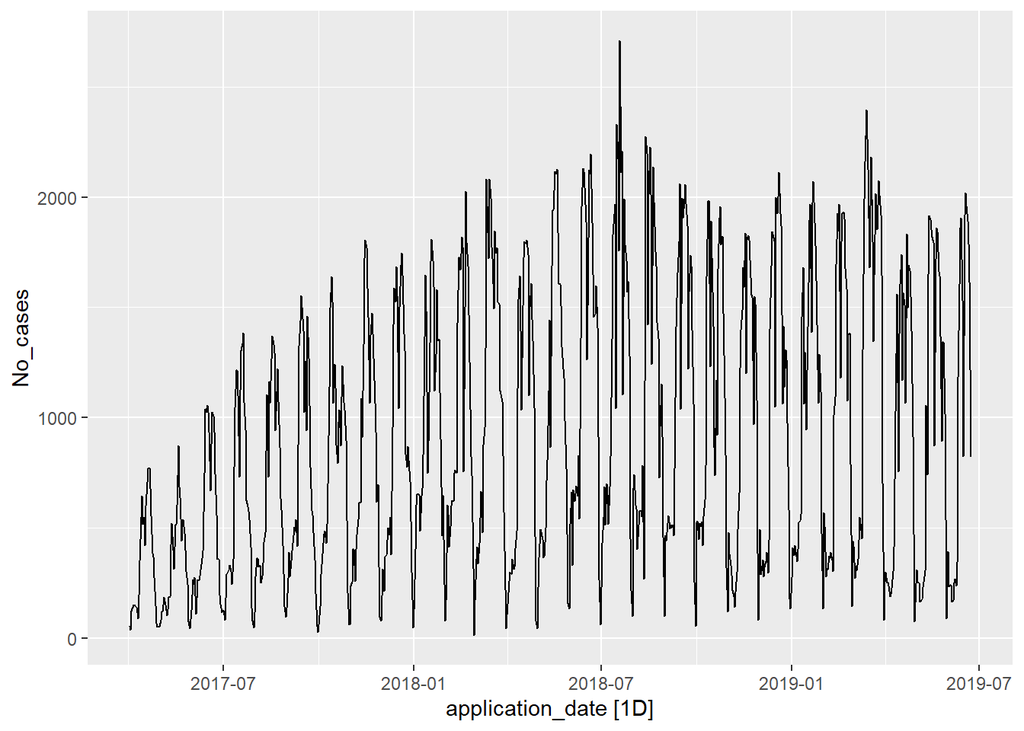

```r
seg_2_ts %>% autoplot(No_cases)
```

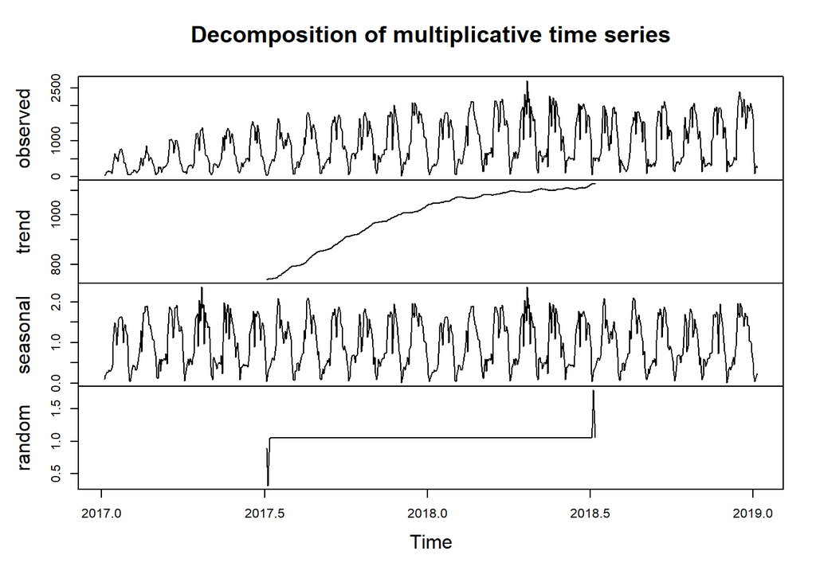

```r
tsdata_decom <- decompose(seg_2_ts2, type = "multiplicative")
plot(tsdata_decom)
```

Trend is obseved.

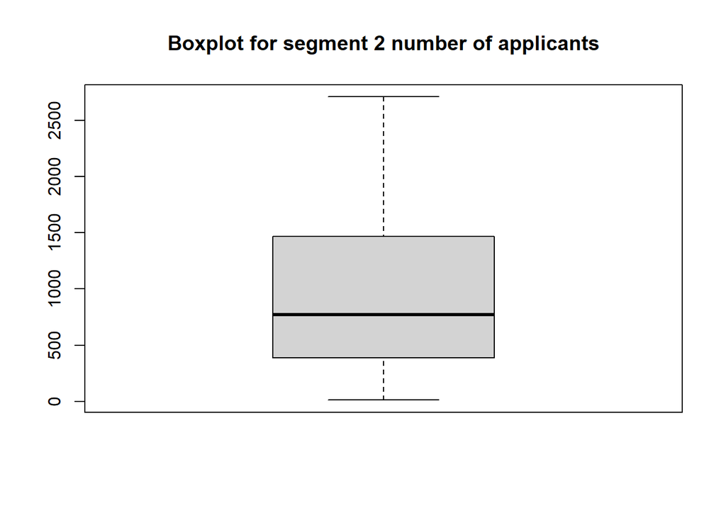

```r
boxplot(seg_2_ts2,main ="Boxplot for segment 2 number of applicants")
```

The output variable contains no outliers.

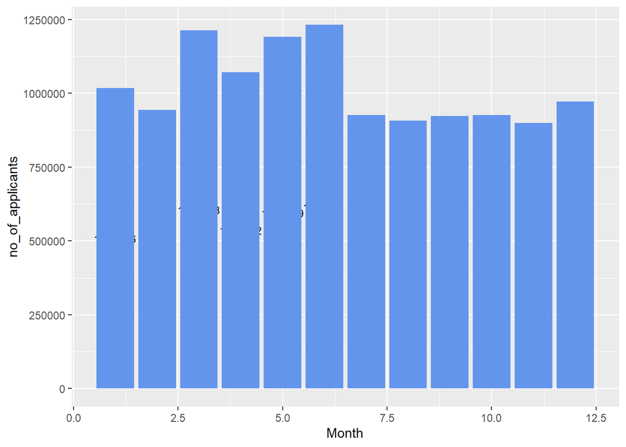

```r
a<-df_segment2 %>%
          group_by(Month ) %>%
          summarise(no_of_applicants= sum(no_of_applicants),.groups='drop')

ggplot(a,
       aes(x = Month,
           y = no_of_applicants)) +
   geom_text(aes(label = no_of_applicants),
            size = 3,
            position = position_stack(vjust = 0.5)) +
  geom_bar(stat = "identity",fill = "cornflowerblue")
```

The number of applicants is higher in the months of June and March.

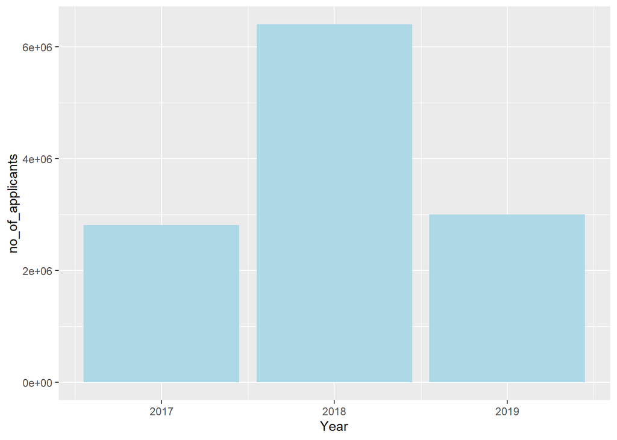

```r
b<-df_segment2 %>%
          group_by(Year ) %>%
          summarise(no_of_applicants= sum(no_of_applicants),.groups='drop')
ggplot(b,
       aes(x = Year,
           y = no_of_applicants)) +
   geom_text(aes(label = no_of_applicants),
            size = 3,
            position = position_stack(vjust = 0.5)) +
  geom_bar(stat = "identity",fill = "lightblue")
```

The year 2018 contains the most number of applicants.The count of applicants for the year 2017 and 2019 is almost the same.

# MODELING

## ARIMA - Autoregressive Integrated Moving Average

The Autoregressive Integrated Moving Average (ARIMA) model uses time-series data and statistical analysis to interpret the data and make future predictions. The ARIMA model aims to explain data by using time series data on its past values and uses linear regression to make predictions.

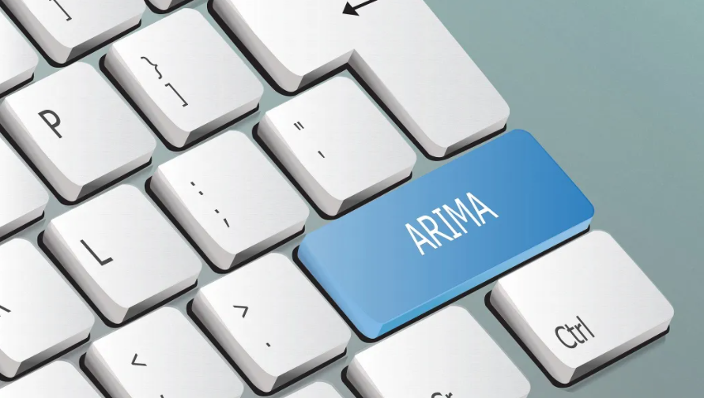

The following descriptive acronym explains the meaning of each of the key components of the ARIMA model:

- The “AR” in ARIMA stands for autoregression, indicating that the model uses the dependent relationship between current data and its past values. In other words, it shows that the data is regressed on its past values.
- The “I” stands for integrated, which means that the data is stationary. Stationary data refers to time-series data that’s been made “stationary” by subtracting the observations from the previous values.
- The “MA” stands for moving average model, indicating that the forecast or outcome of the model depends linearly on the past values. Also, it means that the errors in forecasting are linear functions of past errors. Note that the moving average models are different from statistical moving averages.

Each of the AR, I, and MA components are included in the model as a parameter. The parameters are assigned specific integer values that indicate the type of ARIMA model. A common notation for the ARIMA parameters is shown and explained below:

**ARIMA (p, d, q)**

- The parameter p is the number of autoregressive terms or the number of “lag observations.” It is also called the “lag order,” and it determines the outcome of the model by providing lagged data points.
- The parameter d is known as the degree of differencing. it indicates the number of times the lagged indicators have been subtracted to make the data stationary.
- The parameter q is the number of forecast errors in the model and is also referred to as the size of the moving average window.

#### Partial Autocorrelation Correlation Function

In time series analysis, the partial autocorrelation function (PACF) gives the partial correlation of a stationary time series with its own lagged values, regressed the values of the time series at all shorter lags. It contrasts with the autocorrelation function, which does not control for other lags and p (autoregression term) for ARIMA is contributed by this graph.

#### AutoCorrelation Function:

The autocorrelation function is one of the tools used to find patterns in the data. Specifically, the autocorrelation function tells you the correlation between points separated by various time lags.A plot of the autocorrelation of a time series by lag is called the AutoCorrelation Function, or the acronym ACF. This plot is sometimes called a correlogram or an autocorrelation plot.The q (moving average term) for ARIMA is contributed by this graph.

## Augmented Dickey- Fuller Test(ADF)

ADF test is an ‘augmented’ version of the Dickey Fuller test. The ADF test expands the Dickey-Fuller test equation to include high order regressive process in the model.It is a sophisticated approach towards finding whether a time series is stationary or not.

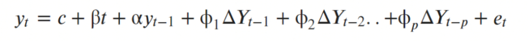

## ARIMA Modeling for Segment 1

### Augmented Dickey- Fuller Test

```r
adf.test(seg_1_ts1)
```

```
##
##  Augmented Dickey-Fuller Test
##
## data:  seg_1_ts1
## Dickey-Fuller = -7.1654, Lag order = 9, p-value = 0.01
## alternative hypothesis: stationary
```

We accept the alternative hypothesis.Therefore, data is stationary.

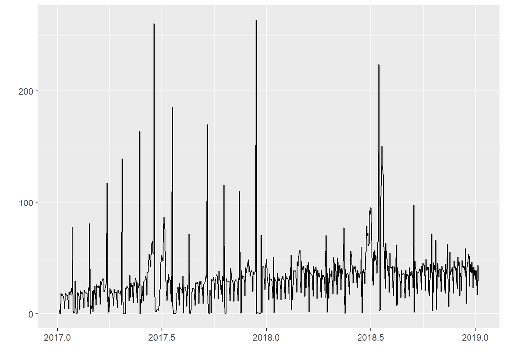

```r
autoplot(seg_1_ts1)
```

### Partial Autocorrelation Correlation Function

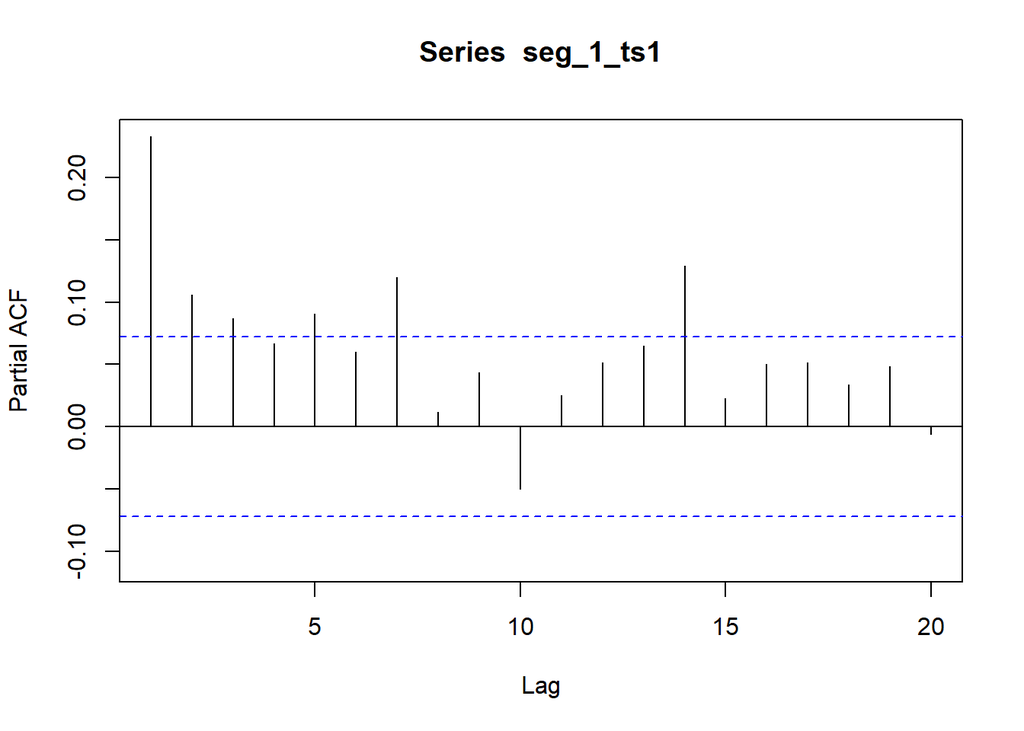

```r
Pacf(seg_1_ts1,lag.max = 20)
```

The appropriate lag value is 1, since it has high PACF value and here we consider lag values that are low in magnitude to get appropriate results.

### AutoCorrelation Function

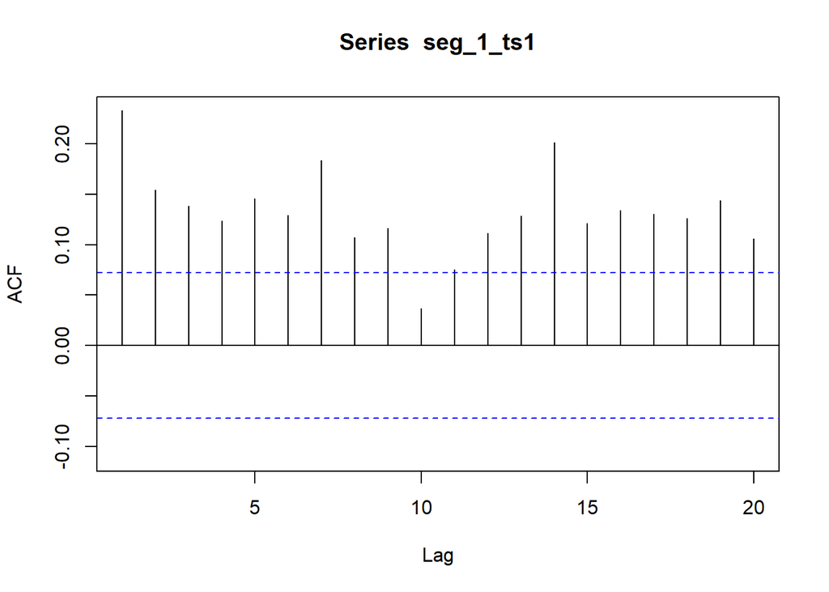

```r
Acf(seg_1_ts1,lag.max=20)
```

The appropriate lag value is 14, since it has high ACF value and here we consider lag values that are low in magnitude to get appropriate results.

### Model Summary for segment 1

```r
tsmod_seg1 <- Arima(y=seg_1_ts1, order = c(1,0,14))
print(tsmod_seg1)
```

```
## Series: seg_1_ts1
## ARIMA(1,0,14) with non-zero mean
##
## Coefficients:
##          ar1      ma1      ma2      ma3      ma4     ma5      ma6     ma7
##       0.9493  -0.8105  -0.0874  -0.0049  -0.0188  0.0200  -0.0108  0.0713
## s.e.  0.0177   0.0410   0.0477   0.0480   0.0477  0.0479   0.0482  0.0475
##           ma8     ma9     ma10    ma11    ma12    ma13    ma14     mean
##       -0.0575  0.0243  -0.0992  0.0402  0.0123  0.0307  0.0821  31.7674
## s.e.   0.0460  0.0477   0.0495  0.0532  0.0489  0.0466  0.0378   3.2221
##
## sigma^2 estimated as 572.2:  log likelihood=-3359.77
## AIC=6753.54   AICc=6754.39   BIC=6831.69
```

### Forecasted Values for segment 1 (Next 30 days)

```r
pred_data_1 = data.frame(forecast(tsmod_seg1, h= 30))
pred_data_1$Point.Forecast
```

```
##  [1] 38.88201 37.50202 37.95681 36.39305 34.86400 36.39808 35.81085 37.53962
##  [9] 34.94549 35.41922 33.33843 31.83778 32.18170 31.41898 31.43666 31.45343
## [17] 31.46936 31.48447 31.49882 31.51244 31.52537 31.53765 31.54930 31.56036
## [25] 31.57086 31.58083 31.59029 31.59928 31.60780 31.61590
```

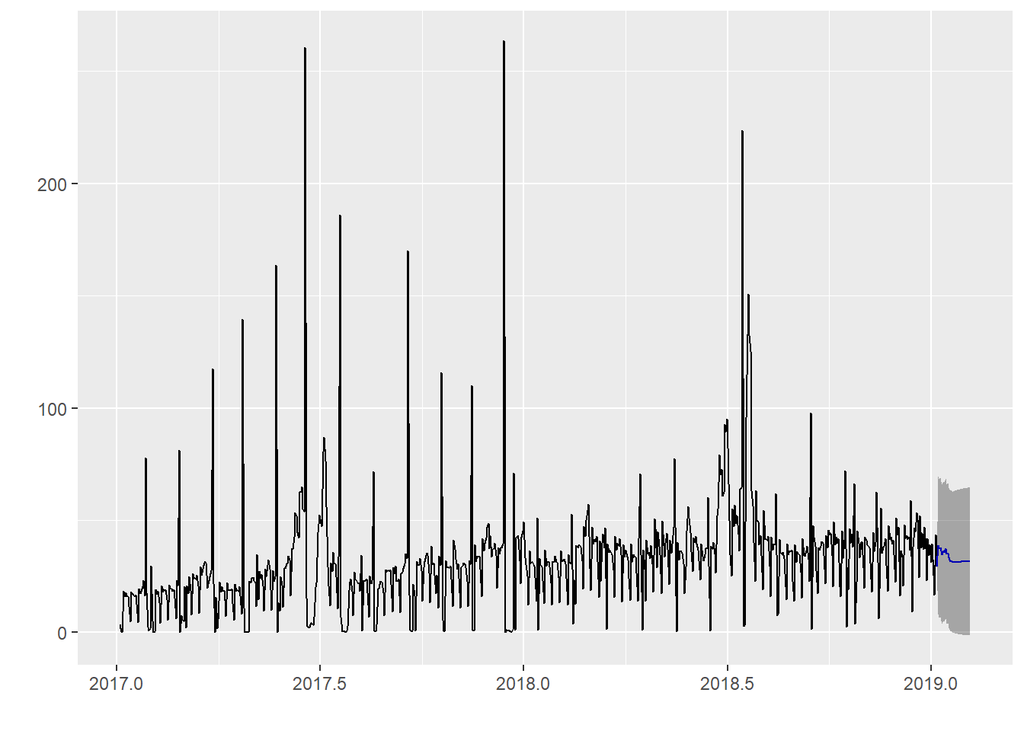

```r
autoplot(forecast(tsmod_seg1, h= 30))
```

## ARIMA Model for Segment 2

### Augmented Dickey- Fuller Test

```r
adf.test(seg_2_ts2)
```

```
##
##  Augmented Dickey-Fuller Test
##
## data:  seg_2_ts2
## Dickey-Fuller = -11.551, Lag order = 9, p-value = 0.01
## alternative hypothesis: stationary
```

We accept the alternative hypothesis.Therefore, data is stationary.

### Partial Autocorrelation Correlation Function

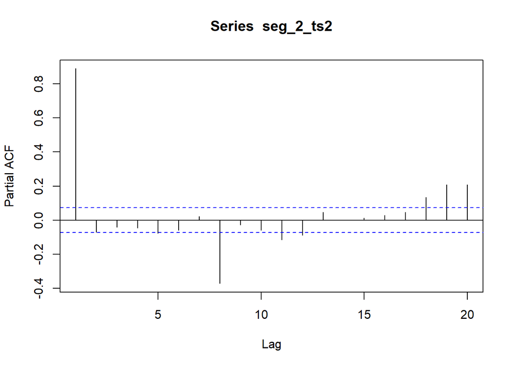

```r
Pacf(seg_2_ts2,lag.max = 20)
```

The appropriate lag value is 1, since it has high PACF value and here we consider lag values that are low in magnitude to get appropriate results.

### AutoCorrelation Function

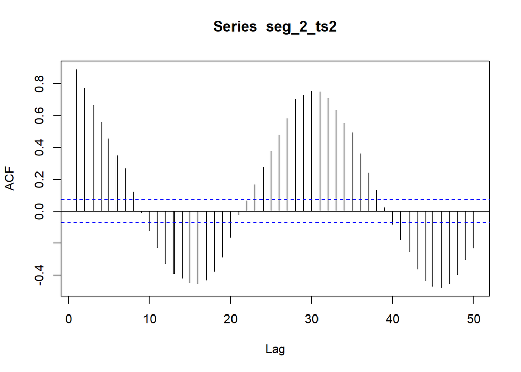

```r
Acf(seg_2_ts2,lag.max=50)
```

The appropriate lag value is 1, since it has high ACF value and here we consider lag values that are low in magnitude to get appropriate results.

```r
tsmod_seg2 <- Arima(y=seg_2_ts2, order = c(1,0,1))
print(tsmod_seg2)
```

```
## Series: seg_2_ts2
## ARIMA(1,0,1) with non-zero mean
##
## Coefficients:
##          ar1     ma1      mean
##       0.8760  0.0709  918.7352
## s.e.  0.0198  0.0397   90.6347
##
## sigma^2 estimated as 82582:  log likelihood=-5188.72
## AIC=10385.44   AICc=10385.49   BIC=10403.83
```

### Forecasted Values for segment 2 (Next 30 days)

```r
pred_data_2 = data.frame (forecast(tsmod_seg2, h= 30))
no_of_applicants=c(pred_data_2$Point.Forecast,pred_data_2$Point.Forecast)
pred_data_2$Point.Forecast
```

```
##  [1] 325.4081 398.9685 463.4089 519.8600 569.3123 612.6336 650.5839 683.8291
##  [9] 712.9527 738.4655 760.8152 780.3940 797.5455 812.5705 825.7328 837.2631
## [17] 847.3640 856.2126 863.9641 870.7546 876.7032 881.9143 886.4793 890.4784
## [25] 893.9816 897.0506 899.7390 902.0941 904.1573 905.9646
```

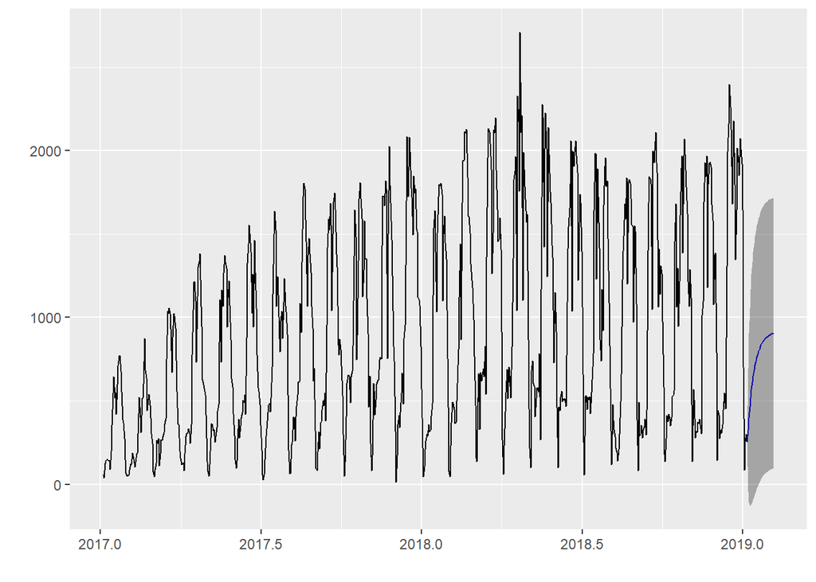

```r
autoplot(forecast(tsmod_seg2, h= 30))
```

# RESULT

Mean value for number of applicants were taken based on date of application recieved and the respective forecasts for next 30 days were carried out for each business segment using ARIMA model.